# Exercise 4 — Aggregated Data and Global Spatial Autocorrelation

BSTA 374 · 17.5 points · Due Wednesday, October 14, 2026, 11:59 pm

Author

ANIK DAS · Lehigh University

Published

October 13, 2026

## What this exercise is

Exercises 1–3 ran on data that shipped inside an R package. This one does not. You will work with **real surveillance data** — COVID-19 deaths in the 67 counties of Pennsylvania — and assemble the analysis dataset yourself, the way you would in a health department: a table of counts from one source, county boundaries from another, and a join between them that has to be checked rather than trusted.

From there the exercise follows the sequence of the last two weeks:

1. join and project the data;
2. compute crude rates, **expected counts**, and the **standardized mortality ratio (SMR)**;
3. map the SMR honestly — which, for a ratio, is not the same as mapping a rate;
4. build a spatial weights matrix and ask, with **global Moran’s I**, whether the SMRs are spatially structured or could plausibly be arranged at random.

It is worth 17.5 points and carries more weight than the first two exercises. Start early: Part A is where most of the unexpected problems will be.

**ImportantSubmission**

Render the exercise as a page of your course site and push it to GitHub, as for Exercises 2 and 3. Then submit to Course Site:

- `LASTNAME_FI_Exercise4.qmd` — the source
- the URL of the rendered page on your GitHub Pages site

Example: `DELMELLE_EM_Exercise4.qmd`. Put your name in the document header.

**Due Wednesday, October 14, 2026 at 11:59 pm.** Late work loses 20% per day unless you arrange something with me in advance.

**WarningReproducibility is graded**

Restart R and render from a clean session before you submit. The CSV must be in your repository (put it in a `data/` folder) and be read with a **relative path** — `read_csv("data/...")`, never `C:/Users/...` — or the document will not render on my machine.

## The data

**Counts.** `pa_covid_deaths_2020.csv` is posted on Course Site. It is a subset of the **Johns Hopkins University CSSE COVID-19 Data Repository** (`time_series_covid19_deaths_US.csv`), the source behind the JHU dashboard that was the most widely used COVID-19 tracker in the United States until the project stopped updating in March 2023. The repository compiles counts reported by state health departments — here, the Pennsylvania Department of Health — and attributes deaths to the county of residence.

| Column | Meaning |
| --- | --- |
| `UID`, `FIPS` | JHU identifier; county FIPS code |
| `Admin2` | County name |
| `Province_State` | State |
| `Population` | County population (U.S. Census Bureau 2019 estimate, as carried in the JHU file) |
| `deaths_2020` | Cumulative COVID-19 deaths reported through December 31, 2020 |

Cite the source in your document as: Dong, E., Du, H., & Gardner, L. (2020). An interactive web-based dashboard to track COVID-19 in real time. *The Lancet Infectious Diseases, 20*(5), 533–534, together with the repository URL: https://github.com/CSSEGISandData/COVID-19.

**Boundaries.** County polygons come from the U.S. Census Bureau’s **cartographic boundary files**, downloaded inside your document with the `tigris` package. Install it once, in the console — `install.packages(c("tigris", "ggrepel"))` — not inside the document.

**NoteWhy 2020**

Calendar year 2020 is the first pandemic year and the period before vaccines were available. Treat the population as the population at risk for one year.

```r
library(sf)
library(dplyr)
library(readr)
library(ggplot2)
library(patchwork)
library(leaflet)
library(spdep)
library(ggrepel)            # non-overlapping labels
library(tigris)
options(tigris_use_cache = TRUE)   # download once, then reuse

covid <- read_csv("data/pa_covid_deaths_2020.csv")
pa    <- counties(state = "PA", cb = TRUE, year = 2020)
```

## Part A — Assemble the dataset (3 points)

1. Inspect both objects. How many rows does `covid` have, and how many polygons does `pa` have? The two numbers differ. Find the rows responsible and say in one sentence what they are and why they cannot be mapped.
2. Identify the column in each object that identifies a county. Show what the values look like in each, and say why they will not match as they stand.
3. Create a join key in `covid` that matches the one in `pa`, then **join the counts onto the polygons**. Show, with code, that every one of the 67 counties received a count — do not just look at the map.
4. In two or three sentences: why join the table onto the polygons (`left_join(pa, covid)`) rather than the other way around, and what would an **inner** join have hidden from you if the key had been only partly wrong?

**Tip**

Run the obvious join first, `left_join(pa, covid, by = c("GEOID" = "FIPS"))`, and read the error message carefully. It tells you exactly what is wrong. A FIPS code is an **identifier**, not a number: `42001` and `42001.0` are the same number but not the same identifier, and a county such as `01001` in Alabama would lose its leading zero.

### Starting code

```r
# A1
covid
```

```
# A tibble: 69 × 6
        UID  FIPS Admin2    Province_State Population deaths_2020
      <dbl> <dbl> <chr>     <chr>               <dbl>       <dbl>
 1 84042001 42001 Adams     Pennsylvania       103009          88
 2 84042003 42003 Allegheny Pennsylvania      1216045        1009
 3 84042005 42005 Armstrong Pennsylvania        64735          69
 4 84042007 42007 Beaver    Pennsylvania       163929         252
 5 84042009 42009 Bedford   Pennsylvania        47888          94
 6 84042011 42011 Berks     Pennsylvania       421164         565
 7 84042013 42013 Blair     Pennsylvania       121829         175
 8 84042015 42015 Bradford  Pennsylvania        60323          56
 9 84042017 42017 Bucks     Pennsylvania       628270         904
10 84042019 42019 Butler    Pennsylvania       187853         194
# ℹ 59 more rows
```

```r
pa
```

```
Simple feature collection with 67 features and 12 fields
Geometry type: MULTIPOLYGON
Dimension:     XY
Bounding box:  xmin: -80.51989 ymin: 39.7198 xmax: -74.68952 ymax: 42.26986
Geodetic CRS:  NAD83
First 10 features:
    STATEFP COUNTYFP COUNTYNS       AFFGEOID GEOID           NAME
139      42      033 01209175 0500000US42033 42033     Clearfield
140      42      125 01209190 0500000US42125 42125     Washington
141      42      031 01210234 0500000US42031 42031        Clarion
142      42      097 01209186 0500000US42097 42097 Northumberland
143      42      061 01213672 0500000US42061 42061     Huntingdon
499      42      101 01209187 0500000US42101 42101   Philadelphia
500      42      049 01209178 0500000US42049 42049           Erie
501      42      091 01213680 0500000US42091 42091     Montgomery
```

[output cut: 24 more lines]

```r
nrow(covid); nrow(pa)
```

```
[1] 69
```

```
[1] 67
```

```r
# Rows in the table with no matching polygon
anti_join(
  covid,
  st_drop_geometry(pa),
  by = c("Admin2" = "NAME")
)
```

```
# A tibble: 2 × 6
       UID  FIPS Admin2     Province_State Population deaths_2020
     <dbl> <dbl> <chr>      <chr>               <dbl>       <dbl>
1 84080042 80042 Out of PA  Pennsylvania            0           0
2 84090042 90042 Unassigned Pennsylvania            0           0
```

```r
# A2 -- what type is each key?
str(covid$FIPS)
```

```
 num [1:69] 42001 42003 42005 42007 42009 ...
```

```r
str(pa$GEOID)
```

```
 chr [1:67] "42033" "42125" "42031" "42097" "42061" "42101" "42049" "42091" ...
```

```r
# Show example values
head(covid$FIPS)
```

```
[1] 42001 42003 42005 42007 42009 42011
```

```r
head(pa$GEOID)
```

```
[1] "42033" "42125" "42031" "42097" "42061" "42101"
```

```r
# A3 -- a five-character, zero-padded text key
covid <- covid |>
  mutate(GEOID = sprintf("%05d", as.integer(FIPS)))
# Join the counts onto the county polygons
pa_covid <- pa |>
  left_join(covid, by = "GEOID")

# Verify that all 67 counties received a count
nrow(pa_covid)
```

```
[1] 67
```

```r
sum(is.na(pa_covid$deaths_2020))
```

```
[1] 0
```

```r
sum(!is.na(pa_covid$deaths_2020))
```

```
[1] 67
```

```r
# Stop execution if the verification fails
stopifnot(
  nrow(pa_covid) == 67,
  n_distinct(pa_covid$GEOID) == 67,
  !anyNA(pa_covid$deaths_2020)
)
```

Answers:

1. covid has 69 rows, and pa has 67 county polygons. The two extra rows, “Out of PA” and “Unassigned,” cannot be mapped because neither identifies a specific Pennsylvania county.
2. The county code is stored in FIPS in covid and GEOID in pa. FIPS contains numbers such as 42001, while GEOID contains text such as “42033”. They cannot be joined directly because one column is numeric and the other is text.
3. I converted the FIPS codes into five-character text codes called GEOID and used them to join the counts onto the county polygons. The joined dataset has 67 counties and no missing death counts, confirming that every county received a count.
4. Using left_join(pa, covid) keeps the county polygons as the main dataset, so all 67 counties remain available for mapping even if some counts fail to match. If a join key were wrong for a county, that county would remain with a missing count, making the problem visible. An inner join would silently remove that county, hiding the failed match and leaving an incomplete map.

## Part B — Coordinate reference system (1.5 points)

1. What CRS do the Census boundaries arrive in? Geographic or projected?
2. Transform `pa_covid` to a **projected** CRS appropriate for the whole state, and state its EPSG code. Pennsylvania is split between two State Plane zones (North and South) and two UTM zones, so the obvious choices each cover only part of the state — say what you chose and why it is acceptable for a statewide map.
3. One sentence: which of the operations in this exercise actually depend on the projection, and which do not?

### Starting code

```r
# Check the original CRS
st_crs(pa_covid)$input
```

```
[1] "NAD83"
```

```r
st_is_longlat(pa_covid)
```

```
[1] TRUE
```

```r
# Transform to NAD83 / Conus Albers
pa_covid <- st_transform(pa_covid, 5070)

# Verify the new CRS
st_crs(pa_covid)
```

```
Coordinate Reference System:
  User input: EPSG:5070
  wkt:
PROJCRS["NAD83 / Conus Albers",
    BASEGEOGCRS["NAD83",
        DATUM["North American Datum 1983",
            ELLIPSOID["GRS 1980",6378137,298.257222101,
                LENGTHUNIT["metre",1]]],
        PRIMEM["Greenwich",0,
            ANGLEUNIT["degree",0.0174532925199433]],
        ID["EPSG",4269]],
    CONVERSION["Conus Albers",
        METHOD["Albers Equal Area",
            ID["EPSG",9822]],
        PARAMETER["Latitude of false origin",23,
            ANGLEUNIT["degree",0.0174532925199433],
            ID["EPSG",8821]],
        PARAMETER["Longitude of false origin",-96,
            ANGLEUNIT["degree",0.0174532925199433],
            ID["EPSG",8822]],
        PARAMETER["Latitude of 1st standard parallel",29.5,
            ANGLEUNIT["degree",0.0174532925199433],
            ID["EPSG",8823]],
        PARAMETER["Latitude of 2nd standard parallel",45.5,
            ANGLEUNIT["degree",0.0174532925199433],
            ID["EPSG",8824]],
        PARAMETER["Easting at false origin",0,
            LENGTHUNIT["metre",1],
            ID["EPSG",8826]],
        PARAMETER["Northing at false origin",0,
            LENGTHUNIT["metre",1],
            ID["EPSG",8827]]],
    CS[Cartesian,2],
        AXIS["easting (X)",east,
            ORDER[1],
            LENGTHUNIT["metre",1]],
        AXIS["northing (Y)",north,
            ORDER[2],
            LENGTHUNIT["metre",1]],
    USAGE[
        SCOPE["Data analysis and small scale data presentation for contiguous lower 48 states."],
        AREA["United States (USA) - CONUS onshore - Alabama; Arizona; Arkansas; California; Colorado; Connecticut; Delaware; Florida; Georgia; Idaho; Illinois; Indiana; Iowa; Kansas; Kentucky; Louisiana; Maine; Maryland; Massachusetts; Michigan; Minnesota; Mississippi; Missouri; Montana; Nebraska; N…
        BBOX[24.41,-124.79,49.38,-66.91]],
    ID["EPSG",5070]]
```

```r
st_is_longlat(pa_covid)
```

```
[1] FALSE
```

Answer:

1. The Census boundaries arrive in NAD83, EPSG:4269. This is a geographic CRS, meaning locations are recorded as longitude and latitude in degrees.
2. I transformed the county polygons to NAD83 / Conus Albers, EPSG:5070. This projection covers the contiguous United States, including all of Pennsylvania, so it avoids choosing just one State Plane or UTM zone. It preserves area and is suitable for a statewide county map.
3. The projection affects the static maps and placement of proportional symbols. The joins, rates, SMRs, and Moran’s I do not depend on it when the county neighbour relationships stay the same. Leaflet requires a separate copy transformed to EPSG:4326.

## Part C — Counts, rates, expected counts, and the SMR (4.5 points)

1. Compute the **crude COVID-19 mortality rate per 100,000** for 2020 in every county. Report the three highest and three lowest.
2. Make two quick static maps with `ggplot2`, placed side by side: the **number of deaths** as **proportional symbols**, and the **crude rate** as a choropleth with a sequential, colour-blind-safe palette. Both need a legend title with units. In two or three sentences: why is a count shown with symbols rather than a choropleth, which counties stand out on each map, and why do the two maps tell different stories?
3. Compute the **statewide reference rate** $r = \sum_i O_i / \sum_i P_i$, and from it the **expected count** in each county, $E_i = r \times P_i$. Show that $\sum_i E_i = \sum_i O_i$ and explain in one sentence why this must be so.
4. Compute the **SMR**, $O_i / E_i$.
   1. Interpret the SMR of one county of your choice in a full sentence a county commissioner could understand.
   2. Divide each county’s crude rate by the statewide rate and compare with the SMR. Explain why they are identical here, and what $E_i$ would have to take into account for the two to differ. *(This is where we are going later in the semester.)*
5. Compute an exact **95% confidence interval** for every SMR (formula below). Compare the intervals for the two or three counties with the **fewest** deaths with those of the counties with the **highest** SMRs. In three or four sentences: what does this tell you about the extreme values on an SMR map?

**NoteWhere the confidence interval comes from**

Treat the expected count $E$ as a fixed constant and the observed count as Poisson, $O \sim \text{Poisson}(\mu)$ with $\mu = \text{SMR} \times E$. We first find an exact 95% interval for $\mu$ and then divide both ends by $E$.

The lower bound $\mu_L$ is the value of $\mu$ at which observing $O$ **or more** deaths has probability 0.025; the upper bound $\mu_U$ is the value at which observing $O$ **or fewer** has probability 0.025. Because of the link between the Poisson and chi-square distributions, both have a closed form:

$$\mu_L = \tfrac{1}{2}\,\chi^2_{0.025,\;2O}, \qquad
\mu_U = \tfrac{1}{2}\,\chi^2_{0.975,\;2(O+1)} .$$

Dividing by $E$ gives the interval for the SMR:

$$\left[\ \frac{\chi^2_{0.025,\,2O}}{2E}\ ,\ \ \frac{\chi^2_{0.975,\,2(O+1)}}{2E}\ \right].$$

The upper bound uses $2(O+1)$ degrees of freedom and the lower bound $2O$; that asymmetry is what keeps the interval exact when counts are small. When $O = 0$ the lower bound is 0.

**Worked example.** A county with $O = 4$ and $E = 5.57$ has SMR $= 0.72$ and

```r
qchisq(0.025, 2 * 4)       / (2 * 5.57)   # 0.20
qchisq(0.975, 2 * (4 + 1)) / (2 * 5.57)   # 1.84
poisson.test(4, T = 5.57)$conf.int        # same interval: E acts as the "time base"
```

The familiar normal approximation, $\text{SMR} \times \exp(\pm 1.96/\sqrt{O})$, works for counties with many deaths but breaks down for the smallest ones — which are exactly the counties this question is about — and is undefined when $O = 0$.

### Starting code

```r
# C1 — deaths per 100,000 people
pa_covid <- pa_covid |>
  mutate(crude_rate = 100000 * deaths_2020 / Population)

# Three highest rates
pa_covid |>
  st_drop_geometry() |>
  arrange(desc(crude_rate)) |>
  select(NAME, deaths_2020, Population, crude_rate) |>
  head(3)
```

```
            NAME deaths_2020 Population crude_rate
1        Mifflin         119      46138   257.9219
2 Northumberland         226      90843   248.7809
3        Bedford          94      47888   196.2913
```

```r
# Three lowest rates
pa_covid |>
  st_drop_geometry() |>
  arrange(crude_rate) |>
  select(NAME, deaths_2020, Population, crude_rate) |>
  head(3)
```

```
    NAME deaths_2020 Population crude_rate
1  Wayne          18      51361   35.04605
2 Forest           3       7247   41.39644
3 Greene          15      36233   41.39872
```

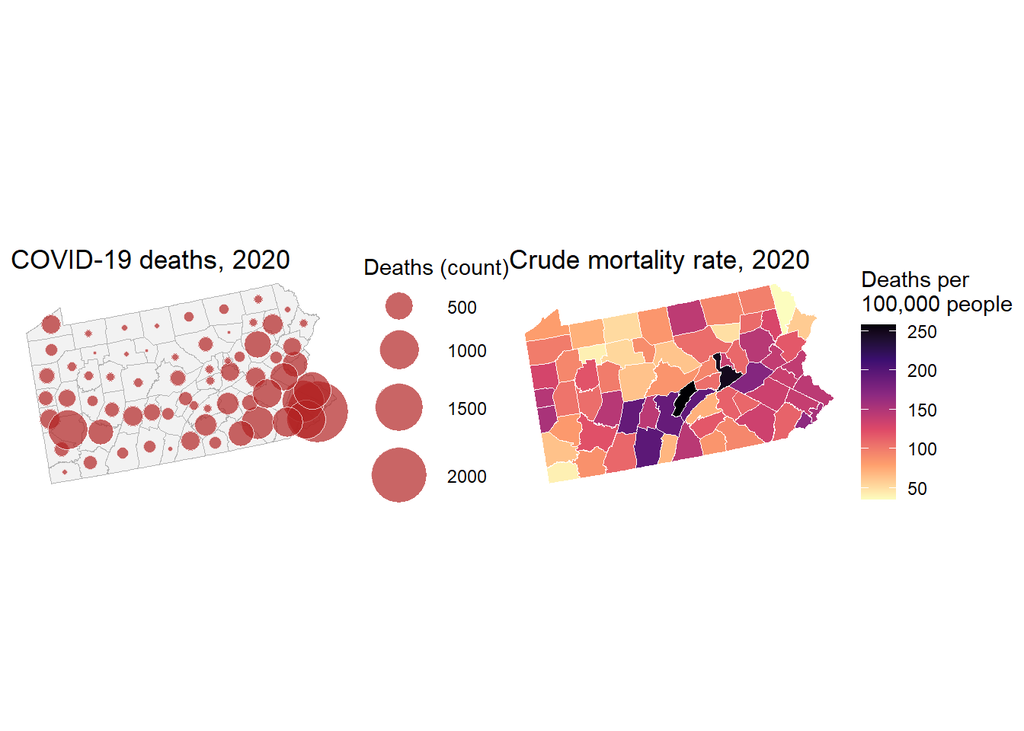

```r
# C2 -- counts as proportional symbols
pts <- st_point_on_surface(pa_covid)        # one point inside each county
p_count <- ggplot() +
  geom_sf(
    data = pa_covid,
    fill = "grey95", colour = "grey70", linewidth = 0.15
  ) +
  geom_sf(
    data = pts, aes(size = deaths_2020),
    shape = 21, fill = "firebrick",
    colour = "white", alpha = 0.7
  ) +
  scale_size_area(max_size = 14, name = "Deaths (count)") +
  labs(title = "COVID-19 deaths, 2020") +
  theme_void()

# Rates as a choropleth
p_rate <- ggplot(pa_covid) +
  geom_sf(
    aes(fill = crude_rate),
    colour = "white", linewidth = 0.15
  ) +
  scale_fill_viridis_c(
    option = "magma", direction = -1,
    name = "Deaths per\n100,000 people"
  ) +
  labs(title = "Crude mortality rate, 2020") +
  theme_void()

p_count + p_rate
```

```r
# Identify counties that stand out on each map
pa_covid |>
  st_drop_geometry() |>
  arrange(desc(deaths_2020)) |>
  select(NAME, deaths_2020, crude_rate) |>
  head(3)
```

```
          NAME deaths_2020 crude_rate
1 Philadelphia        2450   154.6655
2   Montgomery        1147   138.0406
3    Allegheny        1009    82.9739
```

```r
pa_covid |>
  st_drop_geometry() |>
  arrange(desc(crude_rate)) |>
  select(NAME, deaths_2020, crude_rate) |>
  head(3)
```

```
            NAME deaths_2020 crude_rate
1        Mifflin         119   257.9219
2 Northumberland         226   248.7809
3        Bedford          94   196.2913
```

```r
# C3 — statewide reference rate and expected deaths
r <- sum(pa_covid$deaths_2020) / sum(pa_covid$Population)

r * 100000
```

```
[1] 125.2149
```

```r
pa_covid <- pa_covid |>
  mutate(E = r * Population)

sum(pa_covid$E)
```

```
[1] 16030
```

```r
sum(pa_covid$deaths_2020)
```

```
[1] 16030
```

```r
# Check equality, allowing for tiny rounding differences
isTRUE(all.equal(
  sum(pa_covid$E),
  sum(pa_covid$deaths_2020)
))
```

```
[1] TRUE
```

```r
# C4 — SMR and comparison with the rate ratio
pa_covid <- pa_covid |>
  mutate(
    SMR = deaths_2020 / E,
    rate_ratio = crude_rate / (r * 100000)
  )

isTRUE(all.equal(pa_covid$SMR, pa_covid$rate_ratio))
```

```
[1] TRUE
```

```r
# Example county for interpretation
pa_covid |>
  st_drop_geometry() |>
  filter(NAME == "Lehigh") |>
  select(NAME, deaths_2020, E, SMR)
```

```
    NAME deaths_2020        E      SMR
1 Lehigh         503 462.4412 1.087706
```

```r
# C5 — exact 95% Poisson confidence intervals
pa_covid <- pa_covid |>
  mutate(
    SMR_lo = if_else(
      deaths_2020 == 0,
      0,
      qchisq(0.025, 2 * deaths_2020) / (2 * E)
    ),
    SMR_hi = qchisq(0.975, 2 * (deaths_2020 + 1)) / (2 * E)
  )

# Three counties with the fewest deaths
pa_covid |>
  st_drop_geometry() |>
  arrange(deaths_2020, NAME) |>
  select(NAME, deaths_2020, E, SMR, SMR_lo, SMR_hi) |>
  head(3)
```

```
      NAME deaths_2020        E       SMR     SMR_lo    SMR_hi
1   Forest           3 9.074325 0.3306031 0.06817831 0.9661626
2 Sullivan           3 7.595537 0.3949688 0.08145206 1.1542664
3  Cameron           4 5.568307 0.7183511 0.19572651 1.8392642
```

```r
# Three counties with the highest SMRs
pa_covid |>
  st_drop_geometry() |>
  arrange(desc(SMR)) |>
  select(NAME, deaths_2020, E, SMR, SMR_lo, SMR_hi) |>
  head(3)
```

```
            NAME deaths_2020         E      SMR   SMR_lo   SMR_hi
1        Mifflin         119  57.77166 2.059834 1.706401 2.464898
2 Northumberland         226 113.74899 1.986831 1.736223 2.263451
3        Bedford          94  59.96292 1.567635 1.266809 1.918389
```

Answer

1. The three highest rates were Mifflin (257.92), Northumberland (248.78), and Bedford (196.29) deaths per 100,000 people. The three lowest were Wayne (35.05), Forest (41.396), and Greene (41.399) deaths per 100,000 people.
2. Proportional symbols show death counts through circle area, so geographically large counties do not appear more important simply because of their size. Philadelphia, Montgomery, and Allegheny stand out for total deaths, while Mifflin, Northumberland, and Bedford have the highest crude rates. The maps tell different stories because counts show the total burden, while rates show deaths relative to population size.
3. The statewide mortality rate was 125.21 deaths per 100,000 people. Both total expected and total observed deaths equal 16,030. They must be equal because the reference rate is total observed deaths divided by total population, and multiplying it by each county’s population and adding the results gives back the total observed deaths.
4. 1. Lehigh County recorded 503 deaths, compared with about 462 expected if it had the statewide mortality rate. Its SMR of 1.088 means it recorded approximately 8.8% more deaths than expected.
   2. The SMR and the county-to-state mortality rate ratio are identical here because expected deaths use only population size and the same statewide rate for every county. They could differ if expected deaths also accounted for population characteristics, such as age, using separate reference rates for different groups.
5. The counties with only three or four deaths have much greater uncertainty relative to their SMR estimates. Sullivan’s and Cameron’s intervals include 1, so their results are compatible with the statewide rate, while Forest’s interval lies just below 1. The intervals for the three highest-SMR counties are all above 1, supporting higher mortality under the Poisson model. This shows why an extreme colour on an SMR map should be interpreted alongside the death count and confidence interval.

## Part D — Mapping a ratio (3.5 points)

In Exercise 1 a sequential palette was the right choice for a rate. An SMR is different: it is a ratio with a **meaningful reference value of 1**, and it is **multiplicative** — an SMR of 2 is as far above expected as 0.5 is below it.

1. Map the SMR as an interactive **`leaflet`** map with a **diverging palette centred on 1** and **class breaks you set yourself**. Choose breaks that are symmetric on the ratio scale, and make the class around 1 read as “about as expected”. Justify the palette and the breaks in three or four sentences.
2. Your SMR map meets the standards from Exercise 1 — legend title with units or meaning, thin boundaries, colour-blind-safe palette — and in addition:
   - a **source line** on the map naming the data and the year;
   - a **popup** for each county giving the observed and expected deaths, the SMR, and its 95% interval from C5. This is what makes an interactive map worth having: the reader can check how much evidence stands behind a colour.

**Warning`leaflet` wants longitude and latitude**

Web maps are drawn on a Web Mercator basemap and expect coordinates in **EPSG:4326**. Your `pa_covid` is now projected (Part B), so give `leaflet` a transformed **copy**, `st_transform(pa_covid, 4326)`, and keep the projected object for everything else. Handing it projected coordinates is the most common reason for a blank `leaflet` map.

**TipWhat earns full marks here**

Breaks that follow from what an SMR *means*, not from the distribution of the values. A student who can explain why 0.67 and 1.5 belong in the same break set understands the variable.

### Starting code

```r
# Keep the projected object; make a longitude/latitude copy
pa_wgs <- st_transform(pa_covid, 4326)

# Reciprocal breaks, symmetric around 1 on the ratio scale
brks <- c(0, 1/2, 1/1.5, 1/1.1, 1.1, 1.5, 2, Inf)

pal <- colorBin(
  "RdBu",
  domain = pa_wgs$SMR,
  bins = brks,
  reverse = TRUE,
  right = FALSE
)

# One representative value per class for the legend
legend_values <- c(0.25, 0.60, 0.80, 1, 1.30, 1.75, 2.50)

legend_labels <- c(
  "< 0.50",
  "0.50 to < 0.67",
  "0.67 to < 0.91",
  "0.91 to < 1.10 (about as expected)",
  "1.10 to < 1.50",
  "1.50 to < 2.00",
  "2.00 or more"
)

leaflet(pa_wgs) |>
  addTiles() |>
  addPolygons(
    fillColor = ~pal(SMR),
    fillOpacity = 0.8,
    color = "white",
    weight = 0.6,
    label = ~NAME,
    popup = ~sprintf(
      paste0(
        "<b>%s County</b><br>",
        "Observed deaths: %d<br>",
        "Expected deaths: %.1f<br>",
        "SMR: %.2f<br>",
        "95%% confidence interval: %.2f–%.2f"
      ),
      NAME, deaths_2020, E, SMR, SMR_lo, SMR_hi
    ),
    highlightOptions = highlightOptions(
      weight = 2,
      color = "black",
      bringToFront = TRUE
    )
  ) |>
  addLegend(
    colors = pal(legend_values),
    labels = legend_labels,
    opacity = 0.8,
    title = "SMR: observed / expected deaths",
    position = "bottomright"
  ) |>
  addControl(
    paste0(
      "COVID-19 deaths: JHU CSSE, through Dec. 31, 2020",
      "<br>Population: Census 2019 estimates via JHU",
      "<br>Boundaries: U.S. Census Bureau, 2020",
      "<br>Legend boundaries rounded to two decimals"
    ),
    position = "bottomleft"
  )
```

[interactive chart not shown]

Answer:

1. I used a colour-blind-safe blue–white–red palette, with blue showing fewer deaths than expected and red showing more. The light central class, from approximately 0.91 to 1.10, is labelled “about as expected.” The breaks use reciprocal pairs, such as 0.5 and 2, because half the expected deaths and twice the expected deaths represent equal departures from 1 on the ratio scale. These breaks reflect what the SMR means rather than how the county values are distributed.
2. The map has thin county boundaries and a legend titled “SMR: observed / expected deaths.” A source line identifies the JHU CSSE COVID-19 death data for 2020, the population estimates, and the county boundaries. Clicking a county opens a popup showing its observed deaths, expected deaths, SMR, and 95% confidence interval, allowing readers to check the uncertainty behind its colour.

**Note**

A `leaflet` map is an HTML widget: it appears in the rendered page on your GitHub Pages site, which is where I grade it. It will not appear in a PDF.

## Part E — Spatial weights and global Moran’s I (4 points)

1. Build a **queen contiguity** neighbour list. Report the average number of neighbours, the smallest and largest, and whether any county has none.
2. Convert it to **row-standardized** spatial weights. One sentence: what does row standardization do to a county’s neighbours, and what does the spatial lag of the SMR then represent?
3. Compute **global Moran’s I** for the SMR by permutation with `moran.mc()` (999 simulations; set a seed), and plot the permutation distribution with the observed value marked. Report $I$, its expectation under the null hypothesis, $-1/(n-1)$, and the $p$-value. In three or four sentences: what exactly is the null hypothesis, how does the simulation test it, and is there a spatial signal in the SMRs?
4. Draw the **Moran scatterplot**, with every county labelled and coloured by quadrant. Name two or three counties in the high–high quadrant and two or three in the low–low quadrant, say in one sentence what the slope of the fitted line is, and say in one sentence what Moran’s I does **not** tell you about these counties.

### Starting code

```r
# E1 — queen contiguity neighbours
nb <- poly2nb(pa_covid, queen = TRUE)
summary(nb)
```

```
Neighbour list object:
Number of regions: 67
Number of nonzero links: 342
Percentage nonzero weights: 7.618623
Average number of links: 5.104478
Link number distribution:

 2  3  4  5  6  7  8  9
 3  7 14 18 15  3  5  2
3 least connected regions:
7 21 52 with 2 links
2 most connected regions:
4 67 with 9 links
```

```r
n_neighbours <- card(nb)

c(
  average = mean(n_neighbours),
  smallest = min(n_neighbours),
  largest = max(n_neighbours),
  counties_without_neighbours = sum(n_neighbours == 0)
)
```

```
                    average                    smallest
                   5.104478                    2.000000
                    largest counties_without_neighbours
                   9.000000                    0.000000
```

```r
# E2 — row-standardized weights
lw <- nb2listw(nb, style = "W")

# E3 — global Moran's I with 999 permutations
set.seed(374)
mc <- moran.mc(pa_covid$SMR, lw, nsim = 999)
mc
```

```
    Monte-Carlo simulation of Moran I

data:  pa_covid$SMR
weights: lw
number of simulations + 1: 1000

statistic = 0.28933, observed rank = 1000, p-value = 0.001
alternative hypothesis: greater
```

```r
c(
  observed_I = unname(mc$statistic),
  expected_I = -1 / (nrow(pa_covid) - 1),
  p_value = mc$p.value
)
```

```
 observed_I  expected_I     p_value
 0.28933297 -0.01515152  0.00100000
```

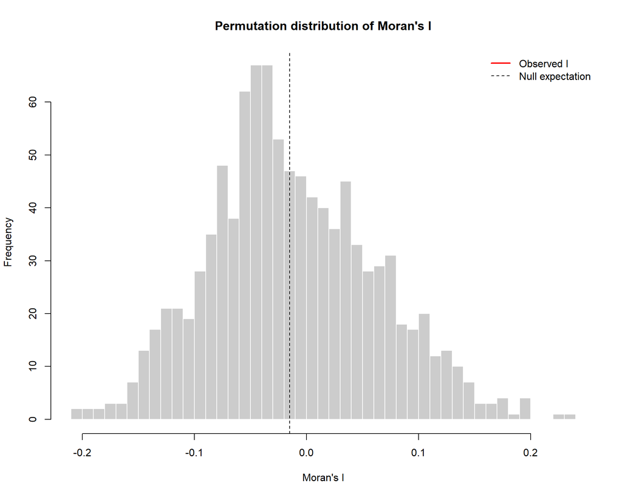

```r
# mc$res includes the observed I as its last element;
# exclude it when plotting the 999 shuffled results
simulated_I <- head(mc$res, -1)

hist(
  simulated_I,
  breaks = 40,
  main = "Permutation distribution of Moran's I",
  xlab = "Moran's I",
  col = "grey80",
  border = "white"
)

abline(v = mc$statistic, col = "red", lwd = 2)
abline(
  v = -1 / (nrow(pa_covid) - 1),
  col = "black", lty = 2
)

legend(
  "topright",
  legend = c("Observed I", "Null expectation"),
  col = c("red", "black"),
  lty = c(1, 2),
  lwd = c(2, 1),
  bty = "n"
)
```

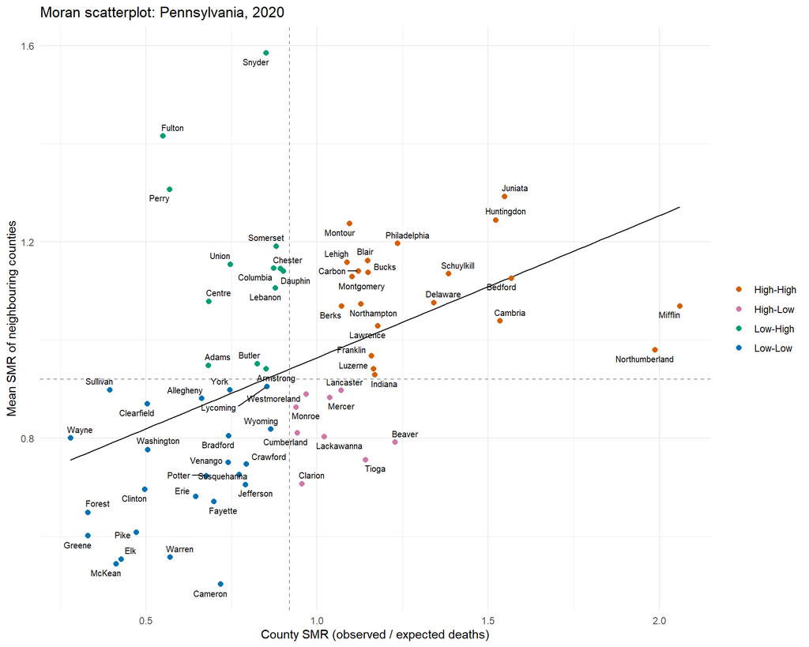

```r
# E4 — spatial lag and scatterplot quadrants
mp_df <- pa_covid |>
  st_drop_geometry() |>
  mutate(
    lag_SMR = lag.listw(lw, SMR),
    quad = case_when(
      SMR >= mean(SMR) & lag_SMR >= mean(SMR) ~ "High-High",
      SMR < mean(SMR) & lag_SMR < mean(SMR) ~ "Low-Low",
      SMR >= mean(SMR) & lag_SMR < mean(SMR) ~ "High-Low",
      TRUE ~ "Low-High"
    )
  )

ggplot(mp_df, aes(SMR, lag_SMR)) +
  geom_hline(
    yintercept = mean(mp_df$SMR),
    linetype = 2, colour = "grey60"
  ) +
  geom_vline(
    xintercept = mean(mp_df$SMR),
    linetype = 2, colour = "grey60"
  ) +
  geom_smooth(
    method = "lm", se = FALSE,
    colour = "black", linewidth = 0.5
  ) +
  geom_point(aes(colour = quad), size = 2) +
  geom_text_repel(
    aes(label = NAME),
    size = 2.6, max.overlaps = Inf,
    seed = 374
  ) +
  scale_colour_manual(
    values = c(
      "High-High" = "#D55E00",
      "Low-Low" = "#0072B2",
      "High-Low" = "#CC79A7",
      "Low-High" = "#009E73"
    )
  ) +
  labs(
    x = "County SMR (observed / expected deaths)",
    y = "Mean SMR of neighbouring counties",
    colour = NULL,
    title = "Moran scatterplot: Pennsylvania, 2020"
  ) +
  theme_minimal()
```

```r
table(mp_df$quad)
```

```
High-High  High-Low  Low-High   Low-Low
       21         9        13        24
```

```r
# Show three examples from each requested quadrant
mp_df |>
  filter(quad == "High-High") |>
  arrange(desc(SMR)) |>
  select(NAME, SMR, lag_SMR, quad) |>
  head(3)
```

```
            NAME      SMR  lag_SMR      quad
1        Mifflin 2.059834 1.070066 High-High
2 Northumberland 1.986831 0.980118 High-High
3        Bedford 1.567635 1.126505 High-High
```

```r
mp_df |>
  filter(quad == "Low-Low") |>
  arrange(SMR) |>
  select(NAME, SMR, lag_SMR, quad) |>
  head(3)
```

```
    NAME       SMR   lag_SMR    quad
1  Wayne 0.2798872 0.8008521 Low-Low
2 Forest 0.3306031 0.6496648 Low-Low
3 Greene 0.3306213 0.6019153 Low-Low
```

```r
# Check that the fitted slope equals Moran's I
c(
  slope = unname(coef(lm(lag_SMR ~ SMR, data = mp_df))[2]),
  Moran_I = unname(mc$statistic)
)
```

```
   slope  Moran_I
0.289333 0.289333
```

Answer:

1. Counties were treated as neighbours if they shared a boundary or a corner. The average number of neighbours was 5.10, the smallest was 2, and the largest was 9. No county had zero neighbours.
2. Row standardization gives each county’s neighbours equal weights that add up to 1, so the spatial lag represents the average SMR of its neighbouring counties.
3. The observed Moran’s I was 0.2893, compared with a null expectation of −0.01515, with a permutation p-value of 0.001. The null hypothesis is that the SMRs are randomly arranged across the counties, with no spatial association under the chosen neighbour relationships. The test shuffled the SMRs across the counties 999 times and compared the resulting Moran’s I values with the observed value. The positive I and small p-value provide strong evidence that counties with similar SMRs tend to be neighbours.
4. Mifflin, Northumberland, and Bedford are examples in the high–high quadrant, while Wayne, Forest, and Greene are examples in the low–low quadrant. The fitted line’s slope is 0.2893, equal to global Moran’s I with these row-standardized weights. Global Moran’s I describes the overall spatial pattern but does not establish whether any individual county belongs to a statistically significant local cluster.

## Part F — Reproducibility and AI use (1 point)

1. The page renders from a clean session and is live on your GitHub Pages site.
2. End the document with an **AI use note**: which tools, what for, at which stage. Two or three sentences.

### AI Use Note

I used ChatGPT to identify the troubleshoot errors, and understand the analysis methods. It also helped interpret my outputs and draft explanations.

## Rubric

| Part | What is assessed | Points |
| --- | --- | --- |
| **A** | Mismatched rows found and explained; key built as text; join verified with code; left vs inner join explained | 3 |
| **B** | Correct projected CRS, stated and justified | 1.5 |
| **C** | Crude rates; count and rate maps compared; reference rate, expected counts and SMR correct; SMR interpreted; small-numbers argument made with intervals | 4.5 |
| **D** | Diverging leaflet map centred on 1 with defended breaks; standards, source line and popup | 3.5 |
| **E** | Weights built and described; Moran’s I by permutation, null hypothesis stated and interpreted; scatterplot read | 4 |
| **F** | Renders from a clean session; published; AI use note | 1 |
|  | **Total** | **17.5** |

Writing counts for roughly 10% of the mark within each part. A submission that is all code and no sentences cannot score above about 60%.

## Getting help

- Moraga §5.1–5.2 (expected counts and SMR) and §5.5 (neighbourhood matrices in `spdep`).
- The `spdep` vignette on neighbour objects: `vignette("nb", package = "spdep")`.
- `?tigris::counties` if the download fails; the same boundaries can be downloaded by hand from the Census Bureau’s cartographic boundary page.
- Office hours, or email me with the code and the exact error message. I am travelling on October 13; email is the fastest route that week.